```python
# Toggle on-off code text
from IPython.display import HTML
HTML('''<script>
code_show=true;
function code_toggle() {
 if (code_show){
 $('div.input').hide();
 } else {
 $('div.input').show();
 }
 code_show = !code_show
}
$( document ).ready(code_toggle);
</script>
<form action="javascript:code_toggle()">
<input type="submit" value="Click to toggle on/off the raw code.">
</form>''')
```

[figure not shown]

# Executive Summary

In China, food and its preparation has been developed so highly that it has reached the status of an art form. Rich and poor, the Chinese people consider that delicious and nutritious food is a basic necessity. There is an old Chinese saying "Food is the first necessity of the people". (Canham, n.d.) History has witnessed the progressions of Chinese cooking in becoming one of the most sought after cuisines worldwide.

# Introduction

A particular community in the U.S which is home to famous restaurants that specializes in Chinese cuisine is found in Chinatown, Las Vegas. Yes, Las Vegas, you heard that right. Aside from the grand neon club parties, high-end dining junctions, and numerous casino betting facilities in famous the Las Vegas Strip, a short drive from the Strip down Spring Mountain Road will put you in Chinatown, a different side of Las Vegas, where you can find mouth-watering meals across a variety of Chinese cuisines for cheaper rates and less pretense. (Kachelriess, 2019) Indeed, doing business in this booming Chinese community is desirable at the very least.

## Objective and Metrics

This study aims to examine the characteristics that Chinese restaurants in Chinatown, Las Vegas have in common through the use of a representative-based clustering algorithm and a dimensionality reduction technique. More specifically, this paper aims to shed insights to:

- Businessmen who want to establish their own Chinese Restaurant in the district.
- Tourists who want to maximize their food exploration journey when to they happen to pass by the area

## Scope and Problem Statements

The data is obtained from Yelp, an American public company headquartered in San Francisco, California which publishes crowd-sourced reviews about businesses. Primarily, the study utilized reviews (i.e. text reviews and rating scores) of Chinese Restaurants in Chinatown, Las Vegas in the hopes of answering the following queries:

- What are the various clusters of Chinese restaurants in Chinatown, Las Vegas?
- Having obtained the clusters, how are these characterized from each other?

# Methodology

[figure not shown]

Libraries and utilities were imported and defined to carry out the abovementioned methodology.

```python
# Libraries and Utilities
import pandas as pd
import numpy as np
import json
import re
from nltk.tokenize import word_tokenize, sent_tokenize
from nltk.corpus import stopwords
from collections import Counter
import matplotlib.pyplot as plt
import seaborn as sns
from wordcloud import WordCloud

# Data Preparation
from datetime import datetime as dt
from sklearn.base import TransformerMixin
from sklearn.utils import resample

# Clustering
from sklearn.cluster import KMeans
from sklearn.metrics import calinski_harabasz_score, silhouette_score
from scipy.spatial.distance import euclidean, cityblock, cosine
from sklearn.base import clone
from sklearn.decomposition import PCA, TruncatedSVD
from sklearn.metrics import confusion_matrix
from pyclustering.cluster.kmedians import kmedians


# ML algo
from sklearn.model_selection import train_test_split
from sklearn.ensemble import RandomForestRegressor
from sklearn.linear_model import LinearRegression, Ridge
from sklearn.linear_model import LogisticRegression, RidgeClassifierCV
from sklearn.tree import DecisionTreeRegressor

# Tf-idf
from sklearn.feature_extraction.text import TfidfVectorizer
from sklearn.feature_extraction.text import CountVectorizer, TfidfTransformer

# SVD
from scipy.linalg import svd
from sklearn.decomposition import TruncatedSVD

# Multioutput
from sklearn.multioutput import MultiOutputRegressor

# Metrics
from sklearn.metrics import explained_variance_score, max_error
from sklearn.metrics import mean_absolute_error, mean_squared_error, r2_score
from sklearn.metrics import adjusted_mutual_info_score as ami
from sklearn.metrics import adjusted_rand_score as ar
```

```python
# Sentence Cleaner
def sentence_cleaner(text, stop_en=[],
          punc='!"#$%&\'()+,-./:;<=>?@[\\]^_`{|}~'):
    """Cleans the sentences (remove stopwords, punctuations, etc."""

    comments = re.compile(r'\[[A-Za-z ]+\]')
    punctuations = punc + '…—‘’“”'

    text = comments.sub('', text)


    clean_para = []
    for para in text.split('\n\n\n'):
        clean_sent = []
        for sent in sent_tokenize(re.sub(r'(\s+)', ' ', para)):
            reconst_sent = ' '.join([word for word in
                                              (sent.lower()
                                                   .translate(
                                                       str.maketrans(
                                                           '',
                                                           '',
                                                           punctuations))
                                                   .split())
                                           if word not in stop_en])
            if reconst_sent:
                clean_sent.append(reconst_sent)
        clean_para.append(' '.join(clean_sent))
    # Rejoining as a paragraph
    text = '\n\n\n'.join(clean_para)

    return text
```

```python
# Word Cloud

def word_cloud(word_freq):
    wc = WordCloud(background_color="white", max_words=2000, max_font_size=256,
           random_state=42, width=1000, height=500, colormap='gist_heat')

    wc.generate_from_frequencies(word_freq)

    return wc

def ngrams(text, n=1):
    """Returns the n-gram of the text.

    An 𝑛-gram is a sequence of 𝑛 successive words in a paragraph of text.

    Parameters
    ----------
    n : int
        Number of successive words, default value is 1

    Returns
    -------
    dict
        Dict-like object with the 𝑛-gram string as keys and
        their counts as values

    Examples
    --------
    >>> analyzer = analyzer = PGalyzer(file_path, True)
    >>> analyzer.ngram(2)
    {'produced by': 1,
     'by greg': 1,
     'greg weeks': 1,
     'weeks dave': 1,
     ...}
    """
    # par_list = self.text.split('\n')
    par_list = text.split('\n\n\n')
    n_words = []

    for par in par_list:
        word_list = par.split()
        if len(word_list) >= n:
            for i in range(len(word_list)-n+1):
                n_words.append(' '.join(word_list[i:i+n]))

    # return dict(Counter(n_words))
    return dict(Counter(n_words).most_common())
```

```python
# Word Cloud Grapher
def cloud_grapher(results, stopwords=[], r=2, c=4, top=None,
                  col_name='sentence', save=None):
    """Generate Wordclouds per cluster arranged from largest to smallest.
    Saves each wordcloud as an image in designated directory"""

    sort_clusters = results.cluster.value_counts().index.to_numpy()
    results = results[results.cluster.map(lambda x: x in sort_clusters)]

    c_nos = sort_clusters if top is None else sort_clusters[:top]

    fig, axes = plt.subplots(nrows=r, ncols=c, figsize=(c*5,r*5))

    for c_no, ax in zip(c_nos, axes.flatten()):
        content = '\n'.join(results[results.cluster == c_no][col_name]
                            .str.replace('.\n', ' ').to_list())
        word_freq = CloudAnalyzer(content).word_count()
        word_freq = {k:v for k, v in word_freq.items()
                         if k not in stopwords_cloud}
        wordcloud = WordCloud(width=800, height=800,
                        background_color='white',
                        stopwords=stopwords,
                        min_font_size=10,
                        ).generate_from_frequencies(word_freq)

        ax.imshow(wordcloud)
        ax.axis('off')
        ax.set_title(f'cluster {c_no}')
        if save is not None:
            filepath = f'{root}/results/wordclouds/{save}_cluster{c_no}.png'
            os.makedirs(os.path.dirname(filepath), exist_ok=True)
            wordcloud.to_file(filepath)
            print(f'cluster {c_no} wordcloud saved as .png at {filepath}')

    print('\n\n')
    for bx in axes.flatten()[len(c_nos):(r*c)-1]:
        bx.axis('off')


    (results[results.cluster.map(lambda x: x in c_nos)].cluster
                                                       .value_counts()
                                                       .plot(kind='bar',
                                                             rot=0,
                                                             title=('cluster '
                                                             'distribution')))

    plt.tight_layout()
    plt.show()

    return axes
```

```python
# Plotting Functions
def scree(variance_explained, thres=0.975):
    """Generates the scree plot and determine minimum number of components
    given a threshold"""

    fig, ax = plt.subplots(figsize=(5,5))

    ax.bar(range(1, len(variance_explained)+1), variance_explained,
           align='center', label='variance')

    ax.set_ylim(0,1)
    ax.set_xlim(0, len(variance_explained)+1)
    ax.set_xlabel('No. of Components (PC for PCA, SV for SVD)')
    ax.set_ylabel('Variance Explained')

    lines, labels = ax.get_legend_handles_labels()

    ax = ax.twinx()
    ax.plot(range(1, len(variance_explained)+1), variance_explained.cumsum(),
            'r-', label='cumulative variance')
    ax.set_ylabel('cumulative variance explained')
    lines2, labels2 = ax.get_legend_handles_labels()
    ax.legend(lines+lines2, labels+labels2)

    ax.axhline(thres, ls='--', color='g')
    k_components = sum(variance_explained.cumsum() <= thres)
    ax.axvline(k_components, ls='--', color='g')
    ax.set_title('Scree plot for explained variance\n'
                 f'For threshold = {thres}, k = {k_components}')
    return ax, k_components

def axis_analysis(svd, features):
    """Conducts topic modelling. Looks what comprises each component"""

    fig, axes = plt.subplots(1, 5, figsize=(20, 4))
    features = np.array(features)
    p = svd.components_.T

    for i, ax in enumerate(axes):

        ind = np.argsort(np.abs(p[:, i]))[-10:]
        ax.barh(features[ind], p[ind, i])
        ax.set_title('Topic Models for SV{x} ({y:0.2f}%)'
                        .format(x=i+1,
                                y=svd.explained_variance_ratio_[i]*100))
        ax.set_xlabel('Magnitude in the SV axis')

    plt.tight_layout()

    return ax

def plot_translated(X_new, feature_names, eigvec, style='PCA', ax1=1, ax2=2,
                    vec_size=2, fontsize=10, xsize = 10, ysize = 5,
                    awidth = 0.05, xlim1 = (-1.5, 1.5), ylim1 = (-1.5, 1.5),
                    xlim2 = (-5, 5), ylim2 = (-5, 5)):
    """Plot the data vs. the first 2 PCs"""

    fig, axes = plt.subplots(1, 2, subplot_kw=dict(aspect='equal'),
                             figsize=(xsize, ysize))
    axes[0].scatter(X_new[:,ax1-1], X_new[:,ax2-1])
    axes[0].set_xlim(xlim1[0], xlim1[1])
    axes[0].set_ylim(ylim1[0], ylim1[1])
    axes[0].set_xlabel(f'component 1')
    axes[0].set_ylabel(f'component 2')

    for feature, vec in zip(feature_names, eigvec):
        axes[1].arrow(0, 0, vec_size*vec[0], vec_size*vec[1], width=awidth,
                      ec='none', fc='r')
        axes[1].text((vec_size+1)*vec[0], (vec_size+1)*vec[1], feature,
                     ha='center', color='k',
                     fontsize=fontsize)

    axes[1].set_xlim(xlim2[0], xlim2[1])
    axes[1].set_ylim(ylim2[0], ylim2[1])
    axes[1].set_xlabel(f'component 1')
    axes[1].set_ylabel(f'component 2')


    return axes
```

```python
# Representative Clustering
class RepresentativeClustering():


    def __init__(self, status=True, random_state=1337):
        """Initialization"""
        self.ys = []
        self.inertias = []
        self.chs = []
        self.scs = []
        self.gss = []
        self.gssds = []
        self.ps = []
        self.amis = []
        self.ars = []
        self.results = {}
        self.clusterer = None
        self.start = 2
        self.stop = 5
        self.status = status
        self.random_state = random_state


    def status_switch(self, switch=True):
        """Turns status on and off"""
        self.status = switch
        return self


    def fit(self, X, y=None):
        """Fit the data"""
        self.X = X
        self.y = y

        return self


    def process(self, clusterer, k_start=2, k_stop=5,
                      gs=False, scs=False,
                      chs=True, ps=True, amis=True, ars=True, dist=euclidean,
                      random_state=1337, b_fold=5):
        """
        Given a set of parameters, return a dictionary of the cluster labels,
        internal validation values, and if actual labels are given, external
        validation values for every k

        Parameters
        ----------
        X : numpy array
            design matrix
        clusteter : object
            clustering object
        k_start:
            initial value to step through
        k_stop:
            final values to step through
        actual: list (optional)
            labels, default None

        Return
        ------
        dict
            Dictionary containing cluster labels and validation (internal and
        external) criteria for every k
        """

        self.clusterer = clusterer
        self.start = k_start
        self.stop = k_stop

        X = self.X
        actual = self.y
        b = b_fold

        random_state = random_state

        for i, k in enumerate(range(k_start, k_stop+1)):

            clusterer_k = clone(clusterer)
            clusterer_k.set_params(n_clusters=k,
                                    random_state=random_state)

            y_k = clusterer_k.fit_predict(X)

            self.ys.append(y_k)

            self.inertias.append(clusterer_k.inertia_)

            y_k = self.ys[i]

            if chs:
                self.chs.append(calinski_harabasz_score(X, y_k))

            if scs:
                self.scs.append(silhouette_score(X, y_k))

            if gs:
                gs = self.gap_statistic(X, y_k, clusterer_k.cluster_centers_,
                                    dist, b,
                                    clone(clusterer).set_params(n_clusters=k),
                                    random_state=random_state)

                self.gss.append(gs[0])
                self.gssds.append(gs[1])

            if actual is not None:
                if ps:
                    self.ps.append(self.purity(y_true=actual, y_pred=y_k))
                if amis:
                    self.amis.append(adjusted_mutual_info_score(actual, y_k))
                if ars:
                    self.ars.append(adjusted_rand_score(actual, y_k))

        keys = ['ys', 'inertias', 'chs', 'scs', 'gss', 'gssds',
                'ps', 'amis', 'ars']

        values = [self.ys, self.inertias, self.chs, self.scs, self.gss,
                  self.gssds, self.ps, self.amis, self.ars]

        self.results =  {k:v  for k, v in
                        zip((keys if actual is not None else keys[:-3]),
                        (values if actual is not None else values[:-3]))}

    def purity(self, y_true, y_pred):
        """Compute the class purity

        Parameters
        ----------
        y_true : array
            List of ground-truth labels
        y_pred : array
            Cluster labels

        Returns
        -------
        purity : float
            Class purity
        """
        # m_ij where i = y_true, j = y_pred
        cm = confusion_matrix(y_true=y_true, y_pred=y_pred)
        # P_j is the max/ dominant class per cluster j
        # M_j is the sum of datapoints per cluster j
        return cm.max(axis=0).sum()/cm.sum(axis=0).sum()


    def export(self, features, k):
        """Export the clustering results by appending to features DataFrame"""

        return (pd.DataFrame(features,
                             columns=features.columns.to_list())
                  .join(pd.DataFrame(self.ys[k-self.start],
                                     columns=['cluster'])))


    def plot_clusters(self, X=None):
        """Plot clusters given the design matrix and cluster labels"""

        X = self.X[:, 0:2] if X is None else X

        ys = self.ys
        #+ 1 from the effect of range generator above. Assumes starts with 2
        k_max = len(ys) + 1
        k_mid = k_max//2 + 2

        fig, ax = plt.subplots(2, k_max//2, sharex=True, sharey=True,
                            figsize=(20,8) , subplot_kw=dict(aspect='equal'),
                            gridspec_kw=dict(wspace=0.01))

        for k,y in zip(range(2, k_max+1), ys):
            if k < k_mid:
                ax[0][k%k_mid-2].scatter(*zip(*X), c=y, s=1, alpha=0.8)
                ax[0][k%k_mid-2].set_title('$k=%d$'%k)
            else:
                ax[1][k%k_mid].scatter(*zip(*X), c=y, s=1, alpha=0.8)
                ax[1][k%k_mid].set_title('$k=%d$'%k)

        return ax


    def plot_internal(self):
        """Plot internal validation values"""

        inertias = self.inertias
        chs = self.chs
        scs = self.scs
        gss = self.gss
        gssds = self.gssds

        fig, ax = plt.subplots(nrows=1, ncols=3, figsize=(15,5))
        ks = np.arange(self.start, self.stop + 1)

        ax[0].plot(ks, inertias, '-o', label='SSE')
        ax[0].plot(ks, chs, '-ro', label='CH')


        lines, labels = ax[0].get_legend_handles_labels()

        ax[1].set_ylabel('Gap statistic/Silhouette')

        try:
            ax[1].errorbar(ks, gss, gssds, fmt='-go', label='Gap statistic')
            ax[2].errorbar(ks, gss, gssds, fmt='-go', label='Gap statistic')
            ax[1].plot(ks, scs, '-ko', label='Silhouette coefficient')
            lines2, labels2 = ax[1].get_legend_handles_labels()
            ax[1].legend(lines+lines2, labels+labels2)
        except Exception:
            ax[1].legend(lines, labels)
            pass

        ax[0].set_title('SSD and Calinsky-Harabazs Score')
        ax[1].set_title('Gap Statistic and Silhouette Score')
        ax[2].set_title('Gap Statistic (close-up)')
        ax[1].set_xlabel('$k$')
        ax[2].set_xlabel('$k$')
        ax[0].set_ylabel('SSE/CH')
        ax[1].set_ylabel('GS/SC')
        ax[2].set_ylabel('Gap Statistic')

        plt.tight_layout()

        return ax


    def plot_external(self):
        """Plot external validation values"""

        ps = self.ps
        amis = self.amis
        ars = self.ars

        fig, ax = plt.subplots(figsize=(5,5))
        ks = np.arange(self.start, self.stop+1)
        ax.plot(ks, ps, '-o', label='PS')
        ax.plot(ks, amis, '-ro', label='AMI')
        ax.plot(ks, ars, '-go', label='AR')
        ax.set_xlabel('$k$')
        ax.set_ylabel('PS/AMI/AR')
        ax.set_title('External Validation Criteria')
        ax.legend()

        return ax


    def gap_statistic(self, X, y, centroids, dist, b, clusterer,
                      random_state=None):
        """Compute the gap statistic

        Parameters
        ----------
        X : array
            Design matrix with each row corresponding to a point
        y : array
            Class label of each point
        centroids : array
            Number of pairs to sample
        dist : callable
            Distance between two points. It should accept two arrays, each
            corresponding to the coordinates of each point
        b : int
            Number of realizations for the reference distribution
        clusterer : KMeans
            Clusterer object that will be used for clustering the reference
            realizations
        random_state : int, default=None
            Determines random number generation for realizations

        Returns
        -------
        gs : float
            Gap statistic
        gs_std : float
            Standard deviation of gap statistic
        """

        rng = np.random.default_rng(random_state)
        max_x = np.max(X, axis=0)
        min_x = np.min(X, axis=0)

        # Obtain the pooled within ssd of the given data
        wk = self.pooled_within_ssd(X, y, centroids, dist)

        wk_i = []
        for _ in range(b):
            # Each realization b will have a unique y_i, centroids_i,
            # We need to initialize the clusterer every time then predict
            # y_i by
            # fitting X_i. Obtain the new centroids using the cluster_centers_
            # attrib.

            X_i = rng.uniform(min_x, max_x, size=X.shape)
            clusterer_i = clone(clusterer)
            clusterer_i.set_params(n_clusters=len(centroids))
            y_i = clusterer_i.fit_predict(X_i)
            centroids_i = clusterer_i.cluster_centers_
            wk_i.append(self.pooled_within_ssd(X_i, y_i, centroids_i, dist))

        return [np.mean(np.log(wk_i))-np.log(wk), np.std(np.log(wk_i))]


    def pooled_within_ssd(self, X, y, centroids, dist):
        """Compute pooled within-cluster sum of squares around the cluster
        mean

        Parameters
        ----------
        X : array
            Design matrix with each row corresponding to a point
        y : array
            Class label of each point
        centroids : array
            Number of pairs to sample
        dist : callable
            Distance between two points. It should accept two arrays, each
            corresponding to the coordinates of each point

        Returns
        -------
        float
            Pooled within-cluster sum of squares around the cluster mean
        """

        return sum([(dist(x_i, centroids[y_i])**2) /(2*(y==y_i).sum())
                    for x_i, y_i in zip(X, y.astype(int))])
```

```python
# Pooled with SSD
def pooled_within_ssd(X, y, centroids, dist):
    """Compute pooled within-cluster sum of squares around the cluster mean

    Parameters
    ----------
    X : array
        Design matrix with each row corresponding to a point
    y : array
        Class label of each point
    centroids : array
        Number of pairs to sample
    dist : callable
        Distance between two points. It should accept two arrays, each
        corresponding to the coordinates of each point

    Returns
    -------
    float
        Pooled within-cluster sum of squares around the cluster mean
    """
    y = y.astype(int)
    total = np.bincount(y)
    result = 0

    for x, y in zip (X, y):
        result += (dist(x, centroids[y])**2/(2*total[y]))

    return result

# Gap Statistic
def gap_statistic(X, y, centroids, dist, b, clusterer, random_state=None):
    """Compute the gap statistic

    Parameters
    ----------
    X : array
        Design matrix with each row corresponding to a point
    y : array
        Class label of each point
    centroids : array
        Number of pairs to sample
    dist : callable
        Distance between two points. It should accept two arrays, each
        corresponding to the coordinates of each point
    b : int
        Number of realizations for the reference distribution
    clusterer : KMeans
        Clusterer object that will be used for clustering the reference
        realizations
    random_state : int, default=None
        Determines random number generation for realizations

    Returns
    -------
    gs : float
        Gap statistic
    gs_std : float
        Standard deviation of gap statistic
    """
    rng = np.random.default_rng(random_state)

    ssd = np.log(pooled_within_ssd(X, y, centroids, dist))
    stats = np.array([])

    for i in range(b):
        X_i = rng.uniform(low = X.min(0), high = X.max(0), size = X.shape)
        y_i = clusterer.fit_predict(X_i)
        ssd_i = np.log(pooled_within_ssd(X_i, y_i,
                                         clusterer.cluster_centers_, dist))
        stats = np.append(stats, (ssd_i - ssd))

    return stats.mean(),stats.std()
```

```python
# Cluster Range
def cluster_range(X, clusterer, k_start, k_stop, actual=None):
    ys = []
    inertias = []
    chs = []
    scs = []
    gss = []
    gssds = []
    ps = []
    amis = []
    ars = []
    for k in range(k_start, k_stop+1):
        clusterer_k = clone(clusterer)
        clusterer_k.set_params(n_clusters = k)
        y = clusterer_k.fit_predict(X)

        ys += [y]
        inertias += [clusterer_k.inertia_]
        chs += [calinski_harabasz_score(X,y)]
        scs += [silhouette_score(X,y)]

        if actual is not None:
            ps += [purity(actual, y)]
            amis += [adjusted_mutual_info_score(actual, y)]
            ars += [adjusted_rand_score(actual, y)]


        gs = gap_statistic(X, y, clusterer_k.cluster_centers_,
                                 euclidean, 5,
                                 clone(clusterer).set_params(n_clusters=k),
                                 random_state=1337)

        gss.append(gs[0])
        gssds.append(gs[1])

    result = {'ys':ys, 'inertias':inertias, 'chs':chs,
              'gss':gss, 'gssds':gssds, 'scs':scs}

    if actual is not None:
        result['ps'] = ps
        result['amis'] = amis
        result['ars'] = ars

    return result

# Plot Clusters
def plot_clusters(X, ys):
    """Plot clusters given the design matrix and cluster labels"""
    k_max = len(ys) + 1
    k_mid = k_max//2 + 2
    fig, ax = plt.subplots(2, k_max//2, dpi=150, sharex=True, sharey=True,
                           figsize=(7,4), subplot_kw=dict(aspect='equal'),
                           gridspec_kw=dict(wspace=0.01))
    for k,y in zip(range(2, k_max+1), ys):
        if k < k_mid:
            ax[0][k%k_mid-2].scatter(*zip(*X), c=y, s=1, alpha=0.8)
            ax[0][k%k_mid-2].set_title('$k=%d$'%k)
        else:
            ax[1][k%k_mid].scatter(*zip(*X), c=y, s=1, alpha=0.8)
            ax[1][k%k_mid].set_title('$k=%d$'%k)
    return ax

def plot_internal(inertias, chs, scs, gss, gssds):
    """Plot internal validation values"""
    fig, ax = plt.subplots()
    ks = np.arange(2, len(inertias)+2)
    ax.plot(ks, inertias, '-o', label='SSE')
    ax.plot(ks, chs, '-ro', label='CH')
    ax.set_xlabel('$k$')
    ax.set_ylabel('SSE/CH')
    lines, labels = ax.get_legend_handles_labels()
    ax2 = ax.twinx()
    ax2.errorbar(ks, gss, gssds, fmt='-go', label='Gap statistic')
    ax2.plot(ks, scs, '-ko', label='Silhouette coefficient')
    ax2.set_ylabel('Gap statistic/Silhouette')
    lines2, labels2 = ax2.get_legend_handles_labels()
    ax2.legend(lines+lines2, labels+labels2)
    return ax
```

```python
# English Stop Words
with open(f'data/stop_en.txt', 'r') as f:
    stop_en = f.read().split()
```

# Data Preparation

```python
df = pd.read_csv('vegas_chinatown.csv').drop(columns = 'Unnamed: 0')
```

The review data that will be covered by this analysis has been filtered from the overall set of reviews from Yelp. (see `DMW_ReviewData.ipynb` for more details on the filtering process)

Generally, details from the `business` table was merged with the `reviews` table in order to obtain information such as city and neighborhood, apart from the `text` content of the review and the corresponding ratings in `stars`. The resulting dataframe is as follows:

```python
df.head()
```

|  | review_id | user_id | business_id | stars_x | date | text | useful | funny | cool | name | ... | state | postal_code | latitude | longitude | stars_y | review_count | is_open | attributes | categories | hours |
| --- | --- | --- | --- | --- | --- | --- | --- | --- | --- | --- | --- | --- | --- | --- | --- | --- | --- | --- | --- | --- | --- |
| 0 | Ku-Hjx5iNEfmqAukQyTMew | AuIK5tF2GjO7SftHawTLKw | L6qd3x0bHymyxub9dF7lIA | 5 | 2009-06-29 | My girlfriend and I love Chinese food speciall... | 0 | 0 | 0 | Cafe Noodle & Chinese Barbeque | ... | NV | 89102 | 36.125878 | -115.197855 | 3.0 | 237 | 1 | {'Alcohol': 'beer_and_wine', 'Ambience': "{'ro... | Chinese, Restaurants, Barbeque, Noodles | {'Monday': '11:0-2:0', 'Tuesday': '11:0-2:0', ... |
| 1 | qMgLu2hihTn38xNJms66-w | gE6J-rXZR8Xa-aAbZxA_RQ | L6qd3x0bHymyxub9dF7lIA | 4 | 2011-11-24 | The Cafe noodle restaurant is where we go when... | 0 | 0 | 0 | Cafe Noodle & Chinese Barbeque | ... | NV | 89102 | 36.125878 | -115.197855 | 3.0 | 237 | 1 | {'Alcohol': 'beer_and_wine', 'Ambience': "{'ro... | Chinese, Restaurants, Barbeque, Noodles | {'Monday': '11:0-2:0', 'Tuesday': '11:0-2:0', ... |
| 2 | zwU3cJRjyvdjZSk08eSLFQ | sNqnKBO0r7VlwOr9A-vdaQ | L6qd3x0bHymyxub9dF7lIA | 4 | 2013-07-24 | We've been going for here for a few months reg... | 1 | 0 | 0 | Cafe Noodle & Chinese Barbeque | ... | NV | 89102 | 36.125878 | -115.197855 | 3.0 | 237 | 1 | {'Alcohol': 'beer_and_wine', 'Ambience': "{'ro... | Chinese, Restaurants, Barbeque, Noodles | {'Monday': '11:0-2:0', 'Tuesday': '11:0-2:0', ... |
| 3 | 6BKtQhdvMYJqZAmsq0m6Mw | ofZROo-BVS4Lcdr7X2u5tA | L6qd3x0bHymyxub9dF7lIA | 1 | 2014-03-19 | horrible experience ! This restaurant makes us... | 2 | 1 | 1 | Cafe Noodle & Chinese Barbeque | ... | NV | 89102 | 36.125878 | -115.197855 | 3.0 | 237 | 1 | {'Alcohol': 'beer_and_wine', 'Ambience': "{'ro... | Chinese, Restaurants, Barbeque, Noodles | {'Monday': '11:0-2:0', 'Tuesday': '11:0-2:0', ... |
| 4 | 6AmXn2a2agVQy3w_DTjxEQ | q6XOqCSxGJehCZIC6cvxjw | L6qd3x0bHymyxub9dF7lIA | 3 | 2013-01-20 | Cheap menu, food is just OK. Good enough for i... | 0 | 0 | 0 | Cafe Noodle & Chinese Barbeque | ... | NV | 89102 | 36.125878 | -115.197855 | 3.0 | 237 | 1 | {'Alcohol': 'beer_and_wine', 'Ambience': "{'ro... | Chinese, Restaurants, Barbeque, Noodles | {'Monday': '11:0-2:0', 'Tuesday': '11:0-2:0', ... |

5 rows × 23 columns

This is an example review from the dataframe above:

```python
df.iloc[0].text
```

```
'My girlfriend and I love Chinese food specially lunch specials.  Cafe Noodle does have the best lunch specials.  Price is cheap and food is delicious but like any other Chinese restaurant, customer service is a little off.'
```

However, we find that there are still words and elements that do hold meaning in helping us guide the restaurant owner and make his ancestors proud. Thus, we will clean the review text prior to processing and analysis.

```python
df_clean = (df.join(df.text
                               .apply(lambda x: sentence_cleaner(x, stop_en=[])),
                        rsuffix='_with_stop')
                  .join(df.text
                               .apply(lambda x: sentence_cleaner(x,
                                                             stop_en=stop_en)),
                        rsuffix='_no_stop')
                  .assign(word_ct_with_stop=lambda x:
                          x.text.str.split().str.len())
                  .assign(word_ct_no_stop=lambda x:
                          x.text.str.split().str.len()))
```

The cleaned review from above will then be:

```python
df_clean.iloc[0].text_no_stop
```

```
'girlfriend love chinese food specially lunch specials cafe noodle best lunch specials price cheap food delicious like chinese restaurant customer service little'
```

The cleaned dataset will contain new columns namely:

- `text_with_stop` where only punctuations were removed and stopword remain in the text
- `text_no_stop` where both punctuations and stopwords were removed from the text
- `word_ct_with_stop` word count for text in `text_with_stop`
- `word_ct_no_stop` word count for text in `text_no_stop`

```python
df_clean.head()
```

|  | review_id | user_id | business_id | stars_x | date | text | useful | funny | cool | name | ... | stars_y | review_count | is_open | attributes | categories | hours | text_with_stop | text_no_stop | word_ct_with_stop | word_ct_no_stop |
| --- | --- | --- | --- | --- | --- | --- | --- | --- | --- | --- | --- | --- | --- | --- | --- | --- | --- | --- | --- | --- | --- |
| 0 | Ku-Hjx5iNEfmqAukQyTMew | AuIK5tF2GjO7SftHawTLKw | L6qd3x0bHymyxub9dF7lIA | 5 | 2009-06-29 | My girlfriend and I love Chinese food speciall... | 0 | 0 | 0 | Cafe Noodle & Chinese Barbeque | ... | 3.0 | 237 | 1 | {'Alcohol': 'beer_and_wine', 'Ambience': "{'ro... | Chinese, Restaurants, Barbeque, Noodles | {'Monday': '11:0-2:0', 'Tuesday': '11:0-2:0', ... | my girlfriend and i love chinese food speciall... | girlfriend love chinese food specially lunch s... | 37 | 37 |
| 1 | qMgLu2hihTn38xNJms66-w | gE6J-rXZR8Xa-aAbZxA_RQ | L6qd3x0bHymyxub9dF7lIA | 4 | 2011-11-24 | The Cafe noodle restaurant is where we go when... | 0 | 0 | 0 | Cafe Noodle & Chinese Barbeque | ... | 3.0 | 237 | 1 | {'Alcohol': 'beer_and_wine', 'Ambience': "{'ro... | Chinese, Restaurants, Barbeque, Noodles | {'Monday': '11:0-2:0', 'Tuesday': '11:0-2:0', ... | the cafe noodle restaurant is where we go when... | cafe noodle restaurant go guests town service ... | 41 | 41 |
| 2 | zwU3cJRjyvdjZSk08eSLFQ | sNqnKBO0r7VlwOr9A-vdaQ | L6qd3x0bHymyxub9dF7lIA | 4 | 2013-07-24 | We've been going for here for a few months reg... | 1 | 0 | 0 | Cafe Noodle & Chinese Barbeque | ... | 3.0 | 237 | 1 | {'Alcohol': 'beer_and_wine', 'Ambience': "{'ro... | Chinese, Restaurants, Barbeque, Noodles | {'Monday': '11:0-2:0', 'Tuesday': '11:0-2:0', ... | weve been going for here for a few months regu... | weve going months regularly keep coming back f... | 100 | 100 |
| 3 | 6BKtQhdvMYJqZAmsq0m6Mw | ofZROo-BVS4Lcdr7X2u5tA | L6qd3x0bHymyxub9dF7lIA | 1 | 2014-03-19 | horrible experience ! This restaurant makes us... | 2 | 1 | 1 | Cafe Noodle & Chinese Barbeque | ... | 3.0 | 237 | 1 | {'Alcohol': 'beer_and_wine', 'Ambience': "{'ro... | Chinese, Restaurants, Barbeque, Noodles | {'Monday': '11:0-2:0', 'Tuesday': '11:0-2:0', ... | horrible experience this restaurant makes us f... | horrible experience restaurant makes feel like... | 125 | 125 |
| 4 | 6AmXn2a2agVQy3w_DTjxEQ | q6XOqCSxGJehCZIC6cvxjw | L6qd3x0bHymyxub9dF7lIA | 3 | 2013-01-20 | Cheap menu, food is just OK. Good enough for i... | 0 | 0 | 0 | Cafe Noodle & Chinese Barbeque | ... | 3.0 | 237 | 1 | {'Alcohol': 'beer_and_wine', 'Ambience': "{'ro... | Chinese, Restaurants, Barbeque, Noodles | {'Monday': '11:0-2:0', 'Tuesday': '11:0-2:0', ... | cheap menu food is just ok good enough for its... | cheap menu food ok good enough price service c... | 16 | 16 |

5 rows × 27 columns

# EDA

```python
from wordcloud import WordCloud

def word_cloud(word_freq):
    wc = WordCloud(background_color="white", max_words=2000, max_font_size=256,
           random_state=42, width=1000, height=500, colormap='gist_heat')

    wc.generate_from_frequencies(word_freq)

    return wc
```

Visualizing all our review text data through a word cloud:

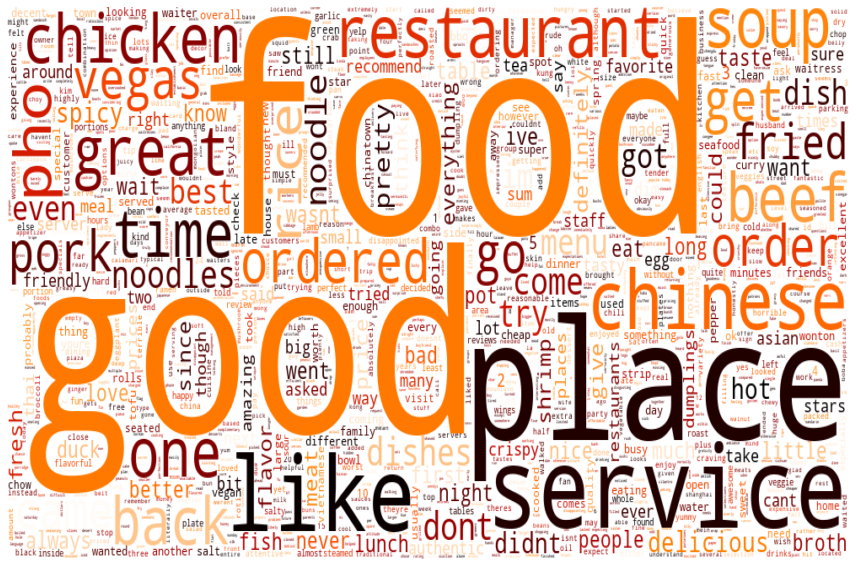

```python
# get word frequency
all_text = df_clean.text_no_stop.str.cat(sep='\n\n\n')
word_freq = dict(Counter(all_text.split()).most_common())
wc = word_cloud(word_freq)

fig, ax = plt.subplots(figsize=(12,8))
ax.imshow(wc, interpolation='bilinear', aspect='auto')
ax.axis('off')

plt.tight_layout()
plt.show()
```

From this word cloud we can see that the words `chinese`, `restaurant`, and `vegas` can be found. Unfornately, these are filters already established from the overall review dataset. Thus, we will add them to our stop words and clean the text data once again. Moreover, we will remove the words `good` and `great` as this will be measured using the ratings while `food` is characteristic of the entire data set.

```python
stop_new = ['chinese', 'restaurant', 'vegas', 'good', 'great', 'food']
```

```python
df_clean = (df.join(df.text
                               .apply(lambda x: sentence_cleaner(x, stop_en=[])),
                        rsuffix='_with_stop')
                  .join(df.text
                               .apply(lambda x: sentence_cleaner(x,
                                                             stop_en=stop_en + stop_new)),
                        rsuffix='_no_stop')
                  .assign(word_ct_with_stop=lambda x:
                          x.text.str.split().str.len())
                  .assign(word_ct_no_stop=lambda x:
                          x.text.str.split().str.len()))

# get word frequency
all_text = df_clean.text_no_stop.str.cat(sep='\n\n\n')
word_freq = dict(Counter(all_text.split()).most_common())
wc = word_cloud(word_freq)
```

## $n$-grams

We then view an $n$-grams plot of the most frequent words in the dataset from single words to compound words of four. From this, we can find meaningful words especially menu items such as `salt pepper pork chops`, `salt pepper chicken wings`, and `spicy beef noodle soup`. Thus we decide to use an ngram range of 1 to 4 moving foward for the rest of our analyses.

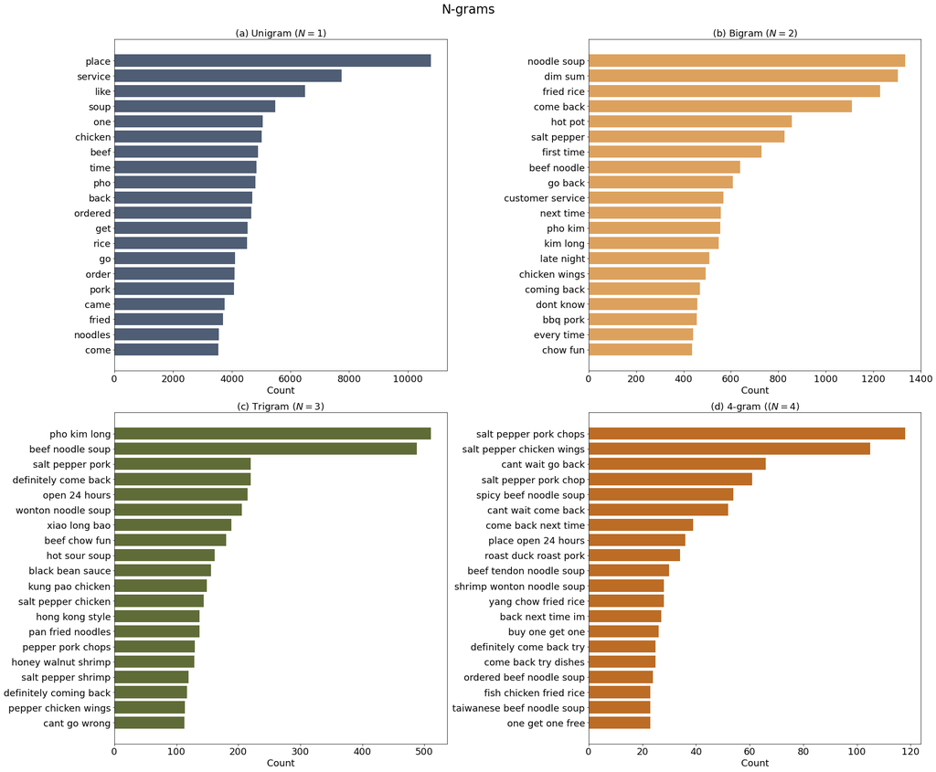

```python
n1 = ngrams(all_text, 1)
n2 = ngrams(all_text, 2)
n3 = ngrams(all_text, 3)
n4 = ngrams(all_text, 4)


fig, ax = plt.subplots(2,2,figsize=(25, 20))

# items to display
n = 20

ax[0][0].barh(list(n1.keys())[:n], list(n1.values())[:n], color='#4f5d75')
ax[0][0].invert_yaxis()
ax[0][0].set_xlabel('Count', fontsize=18)
ax[0][0].set_title('(a) Unigram ($N=1$)', fontsize=18)
ax[0][0].tick_params(labelsize=18)

ax[0][1].barh(list(n2.keys())[:n], list(n2.values())[:n], color='#dda15e')
ax[0][1].invert_yaxis()
ax[0][1].set_xlabel('Count', fontsize=18)
ax[0][1].set_title('(b) Bigram ($N=2$)', fontsize=18)
ax[0][1].tick_params(labelsize=18)

ax[1][0].barh(list(n3.keys())[:n], list(n3.values())[:n], color='#606c38')
ax[1][0].invert_yaxis()
ax[1][0].set_xlabel('Count', fontsize=18)
ax[1][0].set_title('(c) Trigram ($N=3$)', fontsize=18)
ax[1][0].tick_params(labelsize=18)

ax[1][1].barh(list(n4.keys())[:n], list(n4.values())[:n], color='#bc6c25')
ax[1][1].invert_yaxis()
ax[1][1].set_xlabel('Count', fontsize=18)
ax[1][1].set_title('(d) 4-gram (($N=4$)', fontsize=18)
ax[1][1].tick_params(labelsize=18)

#plt.suptitle('N-grams', size=25)
fig.suptitle('N-grams', y=1.025, fontsize=24)

plt.tight_layout()
plt.show()
```

# Dimentionality Reduction

## TF-IDF

```python
print('Shape of df_clean dataframe:')
df_clean.shape
```

```
Shape of df_clean dataframe:
```

```
(15697, 27)
```

With a dataset composed of 15,697 reviews, we would assume a huge set of words that make up the bag of words from the review text data. Thus, we will use a TF-IDF Vectorizer, to create a matrix of TF-IDF features.

```python
tfidf_vec4 = TfidfVectorizer(token_pattern=r'[a-z]+', lowercase=True,
                                   stop_words=stop_en+stop_new,
                                   min_df=0.001,
                                   ngram_range=(1,4), max_features = 2_500)

tfidf_vec4.fit(df_clean.text_no_stop)

text_bow4 = pd.DataFrame.sparse.from_spmatrix(
    tfidf_vec4.fit_transform(df_clean.text_no_stop),
    columns=tfidf_vec4.get_feature_names())
```

We then obtain the matrix below:

```python
text_bow4.head()
```

|  | able | absolute | absolutely | absolutely delicious | accept | acceptable | accommodate | accommodating | according | across | ... | youll | young | youre | youre looking | youve | yum | yum soup | yummy | yunnan | zero |
| --- | --- | --- | --- | --- | --- | --- | --- | --- | --- | --- | --- | --- | --- | --- | --- | --- | --- | --- | --- | --- | --- |
| 0 | 0.0 | 0.0 | 0.0 | 0.0 | 0.0 | 0.0 | 0.0 | 0.0 | 0.0 | 0.0 | ... | 0.0 | 0.0 | 0.0 | 0.0 | 0.0 | 0.0 | 0.0 | 0.000000 | 0.0 | 0.0 |
| 1 | 0.0 | 0.0 | 0.0 | 0.0 | 0.0 | 0.0 | 0.0 | 0.0 | 0.0 | 0.0 | ... | 0.0 | 0.0 | 0.0 | 0.0 | 0.0 | 0.0 | 0.0 | 0.000000 | 0.0 | 0.0 |
| 2 | 0.0 | 0.0 | 0.0 | 0.0 | 0.0 | 0.0 | 0.0 | 0.0 | 0.0 | 0.0 | ... | 0.0 | 0.0 | 0.0 | 0.0 | 0.0 | 0.0 | 0.0 | 0.120311 | 0.0 | 0.0 |
| 3 | 0.0 | 0.0 | 0.0 | 0.0 | 0.0 | 0.0 | 0.0 | 0.0 | 0.0 | 0.0 | ... | 0.0 | 0.0 | 0.0 | 0.0 | 0.0 | 0.0 | 0.0 | 0.000000 | 0.0 | 0.0 |
| 4 | 0.0 | 0.0 | 0.0 | 0.0 | 0.0 | 0.0 | 0.0 | 0.0 | 0.0 | 0.0 | ... | 0.0 | 0.0 | 0.0 | 0.0 | 0.0 | 0.0 | 0.0 | 0.000000 | 0.0 | 0.0 |

5 rows × 2500 columns

## Truncated SVD

To further reduce our dataset into the most meaningful words for our analysis, we perform a Truncated SVD. Using the bag of words with maximum $n$-grams of 4 and with an explained variance threshold of 0.95, we obtain a k of 1829.

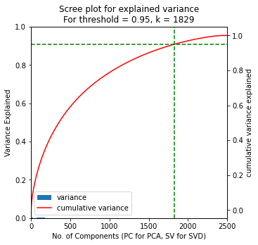

```python
svd = TruncatedSVD(n_components=text_bow4.shape[1]-1, random_state=1337)
svd.fit(text_bow4)

ax, k = scree(svd.explained_variance_ratio_, thres=0.95);
```

Fitting our data to the SVD with `n_components` equal to 1829 as acquired above, we ultimately arrive with an explained variance of 94.85%.

```python
s_svd = TruncatedSVD(n_components=k, random_state=1337)
X_sent = s_svd.fit_transform(text_bow4)

print('Explained Variance: {x:0.2f}%'
      .format(x=100*s_svd.explained_variance_ratio_.sum()))
```

```
Explained Variance: 94.85%
```

# Results and Analysis

## Singular value decomposition and Latent Semantic Analysis

Performing SVD and LSA on our bag of words with maximum ngrams of 4, we obtain the following projection using the first two SV components:

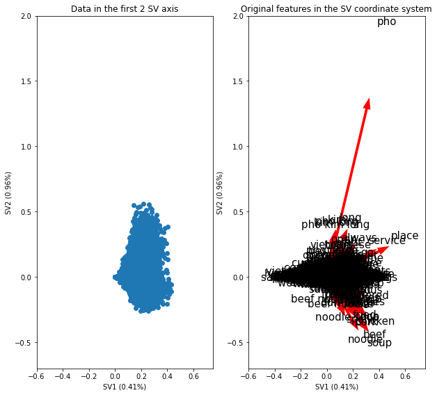

```python
axes = plot_translated(X_sent, text_bow4.columns.to_list(),
                       s_svd.components_.T, fontsize = 15, awidth = 0.02,
                       xsize = 10, ysize = 10,
                       ylim1 = (-0.7, 2), xlim1 = (-0.6, 0.75),
                       ylim2 = (-0.7, 2), xlim2 = (-0.6, 0.75))

axes[0].set_title('Data in the first 2 SV axis')
axes[1].set_title('Original features in the SV coordinate system')
for ax in axes:
    ax.set_xlabel('SV1 ({x:.2f}%)'
                  .format(x=100*s_svd.explained_variance_ratio_[0]))


    ax.set_ylabel('SV2 ({x:.2f}%)'
                  .format(x=100*s_svd.explained_variance_ratio_[1]));
```

From the graph above, we can see that `pho` is the most dominant feature. Unfortunately, pho belongs to Vietnamese cuisine so this is a point that Chinese restaurants may want to address and we will touch on this later in this paper or the Chinese ancestors might punish us. Interestingly, only most reviews do not lie to the direction of this vector. Meanwhile, we have some that emphasize on the words `beef`, `noodle`, and `soup`.

Looking at each SV component, however, we can see better visualize what vectors contribute with greater weights. From this, we can see that, indeed the vectors indentified above, are relevant. This also illustrates barely-distinguishable vectors such as `service` and `place`. Furthermore, the graphs below identified `dim sum` as top vectors for two SV components.

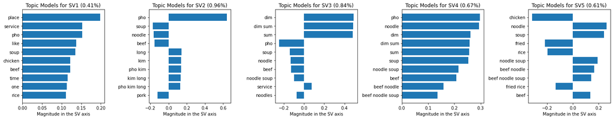

```python
ax = axis_analysis(s_svd, text_bow4.columns.to_list())
```

## $k$-means Representative-Based Clustering

With the features identified above, we now use $k$-means in order to identify the clusters from our dataset.

```python
kmeans_sent = RepresentativeClustering().fit(X=X_sent)
kmeans_sent.process(clusterer=KMeans(random_state=1337), k_start=2, k_stop=11,
          dist=euclidean, gs=True, scs=True)
```

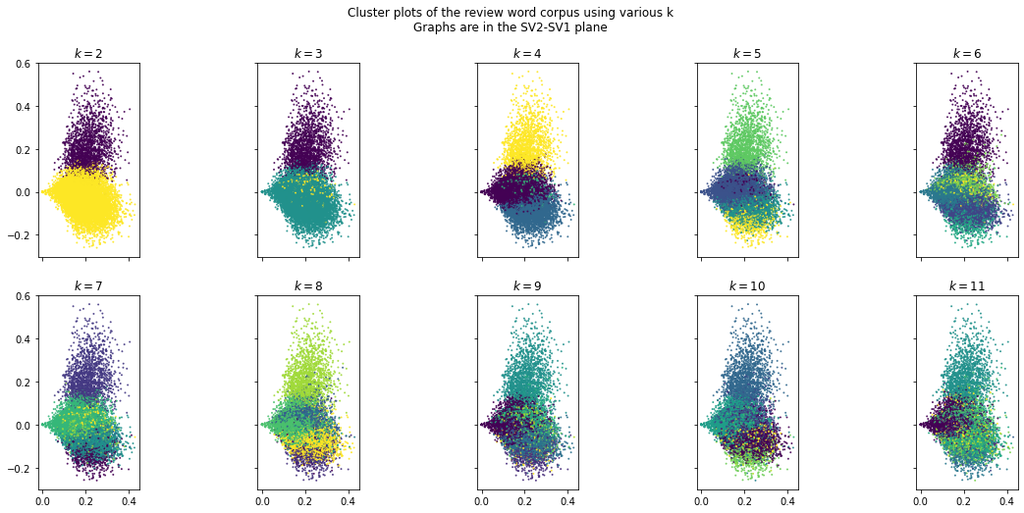

```python
ax = kmeans_sent.plot_clusters();
plt.suptitle('Cluster plots of the review word corpus using various k\n'
             'Graphs are in the SV2-SV1 plane');
```

Given the figures above, the ideal number of clusters is difficult to determine. However, we can see that for k's 5 or less, the clusters are:

- Compact: points in the same cluster are close together with the following exceptions where there are noticeable outliers for `k = 2` and `k = 3`, and an unidentifiable cluster for `k = 4` and `k = 5`.
- Parsimonious: with k of 5 or less, we minimize the number of clusters while obtaining a meaningful interpretation.

To further guide us in choosing the ideal k from those mentioned above, we now investigate their internal validations.

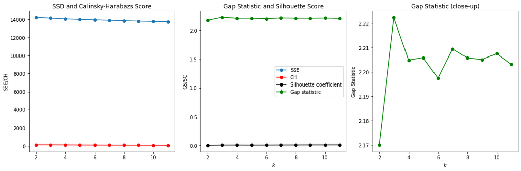

```python
ax = kmeans_sent.plot_internal();
```

In order for us to clearly distinguish the point at which the elbow is determined, we compute for the following values where for each k, its difference from the SSD value of the prior `k` is maximized while the difference from the next `k` is minimized:

```python
rates = {}
for i in range(1,9):
    vals = kmeans_sent.inertias
    before = vals[i-1] - vals[i]
    after = vals[i] - vals[i+1]
    rates[i+2] = {'before': before,
                'after': after,
                'diff': before - after}

pd.DataFrame(rates).T
```

|  | before | after | diff |
| --- | --- | --- | --- |
| 3 | 104.592677 | 78.089012 | 26.503665 |
| 4 | 78.089012 | 58.416437 | 19.672575 |
| 5 | 58.416437 | 48.249027 | 10.167410 |
| 6 | 48.249027 | 47.641198 | 0.607829 |
| 7 | 47.641198 | 50.036815 | -2.395617 |
| 8 | 50.036815 | 41.239969 | 8.796846 |
| 9 | 41.239969 | 35.857558 | 5.382410 |
| 10 | 35.857558 | 25.104520 | 10.753038 |

```python
df_clean['cluster'] = kmeans_sent.ys[2]
```

```python
c0 = df_clean.loc[df_clean['cluster'] == 0]
c1 = df_clean.loc[df_clean['cluster'] == 1]
c2 = df_clean.loc[df_clean['cluster'] == 2]
c3 = df_clean.loc[df_clean['cluster'] == 3]
```

The following table shows the mean and median review scores for each cluster where **cluster 2** stands out to be the lowest and **cluster 1** is highest among the other three clusters in its mean value.

```python
mean = np.array(df_clean[['cluster', 'stars_x']].groupby('cluster').mean())
med = np.array(df_clean[['cluster', 'stars_x']].groupby('cluster').median())

print('Mean and Median of Review Scores for Each Cluster')
mean_med = pd.DataFrame(columns = ['mean', 'median'])
mean_med['mean'] = mean.T.flatten()
mean_med['median'] = med.T.flatten()
mean_med
```

```
Mean and Median of Review Scores for Each Cluster
```

|  | mean | median |
| --- | --- | --- |
| 0 | 3.532414 | 4 |
| 1 | 3.777863 | 4 |
| 2 | 3.079365 | 3 |
| 3 | 3.626875 | 4 |

The following graph also shows how many reviews belong to each cluster:

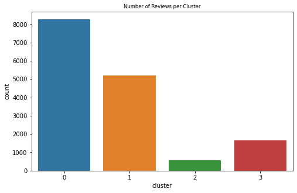

```python
fig = plt.figure(figsize = (8, 5))
ax = sns.countplot(x = 'cluster',data = df_clean[['cluster', 'stars_x']])

font = {'size'   : 7}

plt.rc('font', **font)

plt.title('Number of Reviews per Cluster')
plt.show()
```

```python
def wc_chin(data):
    all_text = data[i].text_no_stop.str.cat(sep='\n\n\n')
    word_freq = dict(Counter(all_text.split()).most_common())

    return word_cloud(word_freq)
```

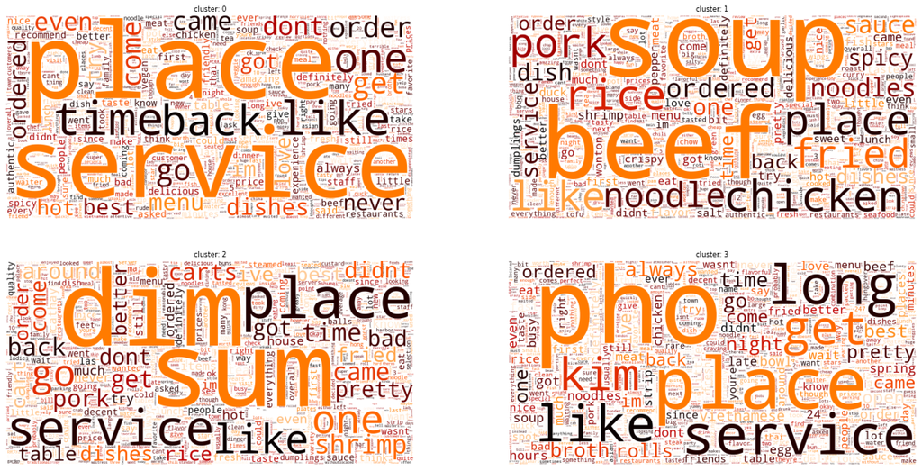

```python
fig = plt.figure(figsize=(20,10))
# fig, ax = plt.subplots(nrows = 2, ncols = 2, figsize=(12,8))
for i in range(4):
    ax = fig.add_subplot(2,2,i+1)
    wordcloud = wc_chin([c0, c1, c2, c3])

    ax.imshow(wordcloud)
    ax.axis('off')

    ax.set_title(f'cluster: {i}')
```

**Cluster 0: Good Experience** It is characteristic of traditional Chinese restaurants to have the best cuisine while needing work on improving customer experience such as the **place** or the **service**. However, this cluster seems to have a characterically decent performance on such aspects with an average rating of **3.5 stars**.

**Cluster 1: Noodle Soup Champions** Who cannot associate **noodle soups** to Chinese restaurants? True to this dish being part of a hearty meal, whether one prefers **chicken**, **pork**, or **beef** to go with it, this cluster definitely champions not just this dish in their menu but also the other restaurants by getting the highest average rating of **3.8 stars**.

**Cluster 2: Dim Sum Cart Haven** To those who aren't familiar with the authentic Chinese restaurant experience, **dim sum** being served in **carts** may test their patience. And the customer's impatience may also affect the mood of our servers bringing the cart around the restaurant. So, while it's reasonable for this cluster to have the lowest average rating of **3.1 stars** due to logistics, if they want the authentic Chinese experience of having freshly prepared and steamed dimsum, then this cluster is the way to go.

**Cluster 3: Pho-sion (Fusion) Cuisine?** Understandably, Vietnam was occupied by Chinese dynasties, but this was already ended many hundreds of years ago. While we have nothing against fusion cuisine, Vietnamese cuisine is already very much alike to some Chinese dishes that makes up any rice noodles or spring rolls. This may be the reason why this cluster of reviews identified thick rice noodle soups as pho dishes. Otherwise, if certain Chinese restaurant owners have started to include pho in their menus then the ancestors will definitely be disappointed. We will not even speak of the decent average rating this cluster got (but it's **3.6 stars**).

# Conclusion and Recommendation

For tourists who will decide to visit Las Vegas, we encourage you to try the various food from the various clusters that we have identified in this study. Aside from maximizing your experience by trying out how the different kinds of Chinese cuisine has been adapated to the palatte of Las Vegas, you also will be helping business owners by adding to the insights they get from a more enriched quality of reviews with your new points of view.

For businessmen who want to establish their own Chinese Restaurant in the district, we understand that you want to assimilate different cultures into your own such as the similar Vietnamese national dish of pho. However, we suggest that you make our ancestors proud by strengthening the brand of Chinese cuisine and avoid association with other culture's dishes. For those who will offer rice noodle dishes in their menu, we encourage you to give it a Chinese name and start to market it as such. Moreover, the average rating of each cluster may be used as a guide on which aspects of a Chinese restaurant to focus your resources on. And if you currently own a Chinese restaurant, then the ratings may also serve as a guide for which aspects you can improve on. If you still want the challenge of handling dim sum in your menu, then we definitely recommend having enough carts to cater to the number of seats occupied in the restaurant at any given time such that there will be less waiting time for customers.

But who knew that Chinese cuisine will become a big hit in Las Vegas, right? Who would have thought 'muricans will know of dim sum, noodle soup, or spring rolls? Those who have paved the way for the spread of Chinese culture: you make our ancestors proud.

# References

- Boom, Godoy, M., Lo Mein Loophole: How U.S. Immigration Law Fueled A Chinese Restaurant, February 2016. NPR. Retrieved from: https://www.npr.org/sections/thesalt/2016/02/22/467113401/lo-mein-loophole-how-u-s-immigration-law-fueled-a-chinese-restaurant-boom#:~:text=Voila!,quadrupled%20between%201910%20and%201920.
- Canham, L. The History Of Chinese Cuisine, n.d. Food Editorial. Retrieved from: https://www.streetdirectory.com/food_editorials/cuisines/asian_food/the_history_of_chinese_cuisine.html
- Rob Kachelriess, Why Everyone Who Visits Vegas Needs to Visit Our Chinatown, May 2019. Thrillist. Retrieved from: https://www.thrillist.com/eat/las-vegas/best-chinatown-restaurants-in-vegas
- Top China Travel, History of Chinese Cuisine, n.d. Top China Travel. Retrieved from: https://www.topchinatravel.com/china-guide/history-of-chinese-cuisine.htm#:~:text=According%20to%20historical%20records%2C%20over,cultivated%20in%20modern%20agriculture%20industry.